# Let’s break some p-values - Part 1

Steph and John

2019-03-19

**Intended level and assumed knowledge**: We figure you know a little about probability, a little about R, a little about hypothesis testing and statistics. We’d like to show you how these fit together. If you’re unfamiliar with these concepts, the footnotes will be your guide (some of the time).

## And so it begins..

*Our location: an office somewhere in Sydney, Australia. It might be well-appointed corporate digs, a slightly underfunded academic building or a cheap cafe somewhere in central Sydney. Choose your own statistical adventure.*

On our Twitter post announcing this blog, Steph made a comment about a would-be podcast, except she and John are the parents of five young kids between them (not together, we hasten to add). Consider this the ‘could have been’ podcast.

**John**: Where do you want to start Steph?

**Steph**: I don’t know, John. I have a lot of pent up rage. Let’s break something.

**John**: We both know you have issues, Steph. We could take a stab at making sense of reproducibility of experiments, prediction, and pre-registration? Even better, we could take a stab at *truth*.

Australian slang for try.

**Steph**: Literally?

**John**: Figuratively. We planned to do something useful, remember?

**Steph**: OK. But these concepts are all really complex. Explain it to me like … I’m a management consultant. There should be a powerpoint and a snappy title.

**John**: No chance. I’ll explain it like I’m a professor of statistics.

**Steph**: My way is funnier. You and Microsoft SmartArt. Just give me five minutes to put a bet down with your grad students.

**John**: My way at least makes sense and has a point.

**Steph**: Fair call. OK, go!

**John**: Alright, it started a few years ago. People started looking into whether particular bits of medical research were reproducible. In particular Ioannidis (2005) tried to reproduce 49 famous medical publications from 1990-2003 resulting from randomized trials: 45 claimed successful intervention;

Ioannidis, John P. A. 2005. “Contradicted and Initially Stronger Effects in Highly Cited Clinical Research.” *JAMA* 294 (2): 218–28.

- 7 (16%) were contradicted;
- 7 others (16%) found effect sizes were exaggerated;
- 20 (44%) were replicated; and
- 11 (24%) remained largely unchallenged.

**John**: There were a number of other papers too, like Pashler and Wagenmakers (2012). The common theme between all of these papers, statistically speaking, is hypothesis testing. One approach at fixing this problem is to pre-register hypothesis testing procedures.

Pashler, Harold, and Eric–Jan Wagenmakers. 2012. “Editors’ Introduction to the Special Section on Replicability in Psychological Science: A Crisis of Confidence?” *Perspectives on Psychological Science* 7 (6): 528–30.

**Steph**: Why is that?

**John**: Well people tended to play around with their analysis by playing games with statistics to get statistical significance (usually $p$-values below 0.05). Pre-registration is the idea that forces researchers to pre-specify how they will analyse their data before they collect it to stop this from happening.

**Steph**: You know what this dialogue needs, John?

**John**: You’re going to tell me, whether I want to hear it or not.

**Steph**: Relateable examples, mate.

At this point, Steph attempted to compile this post for the first time. John, we need to talk about dependencies one of these days.

**John** (thinks): OK so a few years ago my wife was rear-ended while driving and the car was written off so we needed to buy a new car. While we were looking to get a new car my sister in law asked (as a joke) “Are you getting a red car? I heard they’re fast!”

[figure not shown]

**John**: Now I don’t know much about cars at all. So if I went into a car yard I wouldn’t want to buy one that looked like this.

**Steph**: Honestly, John, it’s really not your style. You’re totally not doing the whole mid life crisis thing.

**John**: Fast cars are also expensive cars! But that’s not the point.

**Steph**: Your midlife crisis is not the point?

**John**: I’m not having a midlife crisis.

**Steph**: You’re an academic statistician who just started a blog with a management consultant.

**John**: My judgement is lacking sometimes. There’s a point to this - I wanted to look at a bunch of ways to mess around with hypothesis tests in order to get them to break and my first example related to my sister in law’s joke - and by break I mean the results of the hypothesis test is misleading by telling us that there is a difference between two things when in fact no difference exists in reality.

**Steph**: *Bayesians*.

# Red cars are faster!

Now I’ve had to make a version update to R itself, John. I’m just saying, if you ever had to put code into production…

Let’s imagine a simplified world, such as is suitable for management consultants and students of statistics:

Suppose that

For the record, this proof is John’s but Steph had time to take all the math-speak away while trying to update all those dependencies. Y’all can thank me later.

- There are only two car colours - **red** cars and **blue** cars and we describe them with the variable $\mbox{colour}_i$;
- Cars can eiher be **sports** cars or **normal** cars; and we represent them with the variable $\mbox{type}_i$;
- **Sports** cars are more likely to be **red** than **normal** cars
- **sports** cars are generally faster than **normal** cars.

The relationship between the three variables can be visualized by a directed acyclic graph.

Choose your own adventure, but for probability - Steph.

Textor, Johannes, and Benito van der Zander. 2016. *Dagitty: Graphical Analysis of Structural Causal Models*. https://CRAN.R-project.org/package=dagitty.

```r
library(dagitty)
library(ggdag)
```

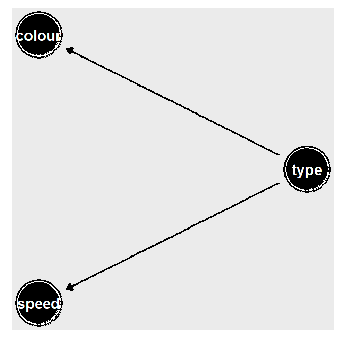

DAG for speed, colour and type

```r
dagified <- dagify(colour ~ type,
                   speed ~ type,
                   exposure = "x",
                   outcome = "speed")
ggdag(dagified, layout = "circle")
```

# Simulating data

To put some probability structure on this let sports cars and normal cars be equally likely:
$$\begin{array}{rl}
{\mathbb P}( \mbox{sports car} ) = 0.5 \\
{\mathbb P}( \mbox{normal car} ) = 0.5 \\
\end{array}$$
and specify conditional probabilities reflecting that sports cars are more likely to be red than normal cars by arbitrarily deciding that:
$$\begin{array}{rl}
{\mathbb P}( \mbox{red car} | \mbox{sports car} ) & = 0.8, \\
{\mathbb P}( \mbox{blue car} | \mbox{sports car} ) & = 0.2, \\
{\mathbb P}( \mbox{red car} | \mbox{normal car} ) & = 0.2, \qquad \mbox{and} \\
{\mathbb P}( \mbox{blue car} | \mbox{normal car} ) & = 0.8. \\
\end{array}$$

Finally, suppose that cars travel on average $\beta_0 = 100$km/h, with sports cars travelling on average $\beta_1 = 50km/h$ higher, with the same standard deviation of $\sigma=25$km/h. Then we can simulate the speed of the $i$th car via
$$\begin{array}{rl}
\mbox{speed}_i
& = \beta_0 + \beta_1 \times {\mathbb I}(\mbox{type}_i=\mbox{sports}) + \varepsilon_i
\\
& = 100 + 50 \times {\mathbb I}(\mbox{type}_i=\mbox{sports}) + \varepsilon_i
\end{array}$$
where independently $\varepsilon_i \sim N(0,25^2)$.

**Steph**: John, you know that some people exist who are allergic to maths, right? So to translate, you made up a situation where the speed of the car is only is related to the colour of the car because red cars are more likely to be sports cars. **John**: Exactly, and this is going to be relevant later.

Let’s simulate some data that captures this scenario using R (R Core Team 2018).

For those of you following along on this epic adventure, Steph is now reinstalling the entire `tidyverse`. On a mobile phone hotspot.

R Core Team. 2018. *R: A Language and Environment for Statistical Computing*. Vienna, Austria: R Foundation for Statistical Computing. https://www.R-project.org/.

```r
# Specify true values of parameters
prob_sport <- 0.5
prob_red_given_sport  <- 0.8
prob_red_given_normal <- 0.2
beta0  <- 100
beta1  <- 50
sd_Val <- 25
n_cars <- 50

# Simulate car type
type <- rbinom(n_cars,1,prob_sport)

# Calculate colour probabilities according to type
prob_colour <- ifelse(type,prob_red_given_sport,prob_red_given_normal)

# Simulate car colours
colour <- rbinom(n_cars,1,prob_colour)

# Simulate car speeds
speed <- beta0 + beta1*type + rnorm(n_cars,sd=sd_Val)

# Convert to tibble and make categories readible
tib <- tibble(colour, speed) %>%
  mutate(
    colour=factor(
        ifelse(colour,"red","blue"),
          levels=c("red","blue")
        )
  )
```

**Steph**: Car type - where’s the car type? **John**: We’re going to break this hypothesis test by dropping an important variable. **Steph**: Breaking, just like I asked for. I note we’re breaking frequentist stuff first. **John**: We’re also simulating a podcast here, for reasons unknown.

# Boxplots and two sample t-tests

Am now reinstalling all dependencies of ggplot2, we better break something real good, John.

Now that we have simulated some data we can create boxplots and try some statistical tests. If we make a boxplot for speed against colour we get:

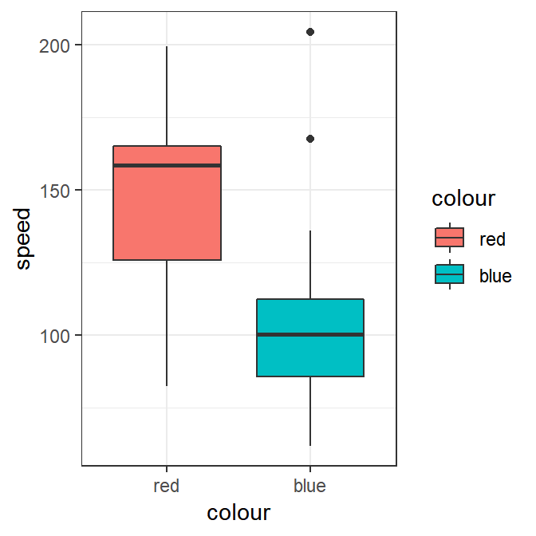

speed vs colour

```r
p <- ggplot(tib, aes(x=colour, y=speed, fill=colour)) +
  geom_boxplot() +
  theme_bw()
p
```

We see that there appears to be a clear difference between the speeds of red and blue cars from the boxplots.

To quantify the difference a two sample $t$-test could be used. We have two sets of points
$${\bf x} = (x_1,\ldots,x_n) \qquad \mbox{and} \qquad {\bf y} = (y_1,\ldots,y_m),$$
corresponding to the speeds of the red and blue cars respectively. We assume that both the ${\bf x}$ and ${\bf y}$ samples are normally distributed:
$$x_i \stackrel{iid.}{\sim} N(\mu_1,\sigma^2),
\qquad \mbox{and} \qquad
y_i \stackrel{iid.}{\sim} N(\mu_2,\sigma^2)$$
where the index ranges are $i=1,\ldots,n$ and $i=1,\ldots,m$, $\mu_1$ and $\mu_2$ are the mean speeds of the red and blue cars respectively, and $\sigma^2$ is a common variance parameter. Let’s consider a hypothesis test of the form
$$H_0 \colon \mu_1 = \mu_2 \qquad \mbox{versus} \qquad H_1 \colon \mu_1 > \mu_2$$
where we have chosen a one sided alternative to indicate our prior belief that red cars are faster than blue cars.

If we wanted to see if red cars were significantly faster than blue cars we could perform a $t$ test using the `tadaatoolbox` package (Burk and Anton 2018).

Burk, Lukas, and Tobias Anton. 2018. *Tadaatoolbox: Helpers for Data Analysis and Presentation Focused on Undergrad Psychology*. https://CRAN.R-project.org/package=tadaatoolbox.

As a corporate data scientist who is currently working through dependency hell, I legit use these all.the.time.

```r
library(tadaatoolbox)
tadaa_t.test(data=tib,
             response=speed,
             group=colour,
             direction="greater",
             print="markdown")
```

Table 1: **Two Sample t-test** with alternative hypothesis: $\mu_1 > \mu_2$

| Diff | $\mu_1$ red | $\mu_2$ blue | t | SE | df | $CI_{95\%}$ | p | Cohen's d | Power |
| --- | --- | --- | --- | --- | --- | --- | --- | --- | --- |
| 40.12 | 145.98 | 105.86 | 4.15 | 9.66 | 48 | (23.92 - Inf) | < 0.001 | 1.2 | 0.99 |

We get statistical significance, which we’d expect because we set up our little universe that way. Fantastic, we didn’t break our own test! (Just Steph’s development environment).

# Reproducibility, prediction and inference

Suppose that we went to a number of “car yards” (i.e., repeated the experiment) where data was generated using the above process and we **only** observed:

- the speed of the cars and the
- the colour of the cars.

Suppose that we repeated the experiment 1000 times, that is we went to 1000 car yards and performed the same two sample t-test on different collected samples at each car yard collecting data for $n=50$ different cars each time.

The idea here is that we have very little certainty about one observation, but about many observations we can be *more* certain. And if anybody has any idea why this build is *Failed with error: ‘package ’ggplot2’ could not be loaded’*, I’d be eternally grateful.

How often would red cars be significantly faster than blue car if we were to repeat the same experiment over and over again, i.e., would our results be reproducible?

```r
# Authors' note: when Steph had to buy a car, she gave up after the first
# car yard and asked her friend who worked at said car yard to sort her
# out. She bought the first car she test drove because she is a great
# believer in not doing boring things, like car yards.
n_car_yards <- 1000

p_values <- c()
for (i in 1:n_car_yards)
{
  # Simulate car type
  type <- rbinom(n_cars,1,prob_sport)

  # Calculate colour probs
  prob_colour <- ifelse(type,prob_red_given_sport,prob_red_given_normal)

  # Simulate car colours
  colour <- rbinom(n_cars,1,prob_colour)

  # Simulate car speeds
  speed <- beta0 + beta1*type + rnorm(n_cars,sd=sd_Val)

  # Perform two-sample t-test
  p_values[i] <- t.test(speed[colour==1],
                        speed[colour==0],
                        alternative="greater")$p.value
}
```

From the above simulations we find that in 94.1 percent of simulations where red cars were statistically significantly faster than blue cars even though the colour of the car has nothing to do with the speed of the car!

So…

- **Reproducibility**: The results would be reproducible roughly 94.1 percent of the time since if we went from car yard to car yard red cars would be generally faster than blue cars. *Pre-registration does not inherently solve this problem of a *spurious relationship* between these variables.*
- **Prediction**: Even though there is no direct relationship between speend and car colour, if we were to pick a car that we wanted to be fast then we would pick a red car and the car would be more likely to be faster than if we picked a blue car. We can still make good predictions from incorrect models.
- **Truth**: But painting our car red would not make it any faster.

**Steph**: Congratulations John, statistics has discovered the age-old econometric problem of the spurious regression. We broke that hypothesis because we were measuring the wrong relationships.

I admit defeat, can’t work out the dependency issue, John hit me up with your dependencies and system environment please!

**John**: Yes, that was my point. With a relateable example. It occurs all the time in science. Researchers don’t know what the true relationship between measurements are so they

- measure what their current theory tells them what is important to measure;
- measure what it is possible or convenient to measure; or
- measure a whole bunch of stuff and hope that something they measure is important.

**Steph**: This happens in field work all.the.time. You think you’re measuring Thing A, when actually Thing B is what’s doing the heavy lifting and Thing B just happens to be correlated with Thing A. (Tylyer Vigen’s site is full of examples of this in real life)[http://www.tylervigen.com/spurious-correlations], in that case, *time itself* is the common Thing B. If you’re working with time series it’s often inevitable without recognising the impact it has.

**John**: Stories for another day?

**Steph**: Sure- next time let’s see what this idea of a *spurious relationship* would look like in a real-world data science context.

**Acknowledgements**: We would like to thank Sarah Romanes, Isabella Ghement, and Shila Ghazanfar for proof-reading and comments.